# Coding_challange_DataWrangling

Arpan

2025-03-19

# Question 1

Download two .csv files from Canvas called DiversityData.csv and Metadata.csv, and read them into R using relative file paths.

```r
diversity<-read.csv("Data_wrangling/DiversityData.csv",na.strings="na") #reading diversity data
meta<-read.csv("Data_wrangling/Metadata.csv") #reading metadata
```

# Question 2

Join the two dataframes together by the common column ‘Code’. Name the resulting dataframe alpha.

```r
library(tidyverse)
alpha<-left_join(diversity, meta, by = "Code") # join two data frame by "code" column
alpha
```

```
##        Code  shannon invsimpson   simpson richness    Crop Time_Point Replicate
## 1    S01_13 6.624921  210.72795 0.9952545     3319    Soil          0         1
## 2    S02_16 6.612413  206.86664 0.9951660     3079    Soil          0         2
## 3    S03_19 6.660853  213.01843 0.9953056     3935    Soil          0         3
## 4    S04_22 6.660671  204.69080 0.9951146     3922    Soil          0         4
## 5    S05_25 6.610965  200.25523 0.9950064     3196    Soil          0         5
## 6    S06_28 6.650812  199.32110 0.9949830     3481    Soil          0         6
## 7    S61_32 6.570679  200.23177 0.9950058     3250    Soil          6         1
## 8    S62_35 6.492227  171.27965 0.9941616     3170    Soil          6         2
## 9    S63_38 6.610986  192.08535 0.9947940     3657    Soil          6         3
## 10   S64_41 6.472259  163.99814 0.9939024     3177    Soil          6         4
## 11   S65_44 6.508824  181.69248 0.9944962     2985    Soil          6         5
## 12   S66_47 6.482495  176.90684 0.9943473     2770    Soil          6         6
## 13  S121_51 6.276073  126.56259 0.9920988     3040    Soil         12         1
## 14  S122_54 6.461118  152.98152 0.9934633     3192    Soil         12         2
```

[output cut: 127 more lines]

# Question 3

Calculate Pielou’s evenness index: Pielou’s evenness is an ecological parameter calculated by the Shannon diversity index (column Shannon) divided by the log of the richness column. a. Using mutate, create a new column to calculate Pielou’s evenness index. b. Name the resulting dataframe alpha_even

```r
alpha_even<-mutate(alpha, even = shannon/log(richness)) #mutating and creating a new column to calculate Pielou’s evenness index.
alpha_even
```

```
##        Code  shannon invsimpson   simpson richness    Crop Time_Point Replicate
## 1    S01_13 6.624921  210.72795 0.9952545     3319    Soil          0         1
## 2    S02_16 6.612413  206.86664 0.9951660     3079    Soil          0         2
## 3    S03_19 6.660853  213.01843 0.9953056     3935    Soil          0         3
## 4    S04_22 6.660671  204.69080 0.9951146     3922    Soil          0         4
## 5    S05_25 6.610965  200.25523 0.9950064     3196    Soil          0         5
## 6    S06_28 6.650812  199.32110 0.9949830     3481    Soil          0         6
## 7    S61_32 6.570679  200.23177 0.9950058     3250    Soil          6         1
## 8    S62_35 6.492227  171.27965 0.9941616     3170    Soil          6         2
## 9    S63_38 6.610986  192.08535 0.9947940     3657    Soil          6         3
## 10   S64_41 6.472259  163.99814 0.9939024     3177    Soil          6         4
## 11   S65_44 6.508824  181.69248 0.9944962     2985    Soil          6         5
## 12   S66_47 6.482495  176.90684 0.9943473     2770    Soil          6         6
## 13  S121_51 6.276073  126.56259 0.9920988     3040    Soil         12         1
## 14  S122_54 6.461118  152.98152 0.9934633     3192    Soil         12         2
```

[output cut: 127 more lines]

# Question 4

Using tidyverse language of functions and the pipe, use the summarise function and tell me the mean and standard error evenness grouped by crop over time. a. Start with the alpha_even dataframe b. Group the data: group the data by Crop and Time_Point. c. Summarize the data: Calculate the mean, count, standard deviation, and standard error for the even variable within each group. d. Name the resulting dataframe alpha_average

```r
alpha_average <- alpha_even %>%
  group_by(Crop, Time_Point) %>% # grouping by crop and time point to later calculate summary stats by group
  summarise(mean.even = mean(even), # calculating the mean richness, stdeviation, and standard error
            n = n(),
            sd.dev = sd(even)) %>%
  mutate(std.err = sd.dev/sqrt(n))
alpha_average
```

```
## # A tibble: 12 × 6
## # Groups:   Crop [3]
##    Crop    Time_Point mean.even     n  sd.dev std.err
##    <chr>        <int>     <dbl> <int>   <dbl>   <dbl>
##  1 Cotton           0     0.820     6 0.00556 0.00227
##  2 Cotton           6     0.805     6 0.00920 0.00376
##  3 Cotton          12     0.767     6 0.0157  0.00640
##  4 Cotton          18     0.755     5 0.0169  0.00755
##  5 Soil             0     0.814     6 0.00765 0.00312
##  6 Soil             6     0.810     6 0.00587 0.00240
##  7 Soil            12     0.798     6 0.00782 0.00319
##  8 Soil            18     0.800     5 0.0104  0.00465
##  9 Soybean          0     0.822     6 0.00270 0.00110
## 10 Soybean          6     0.764     6 0.0400  0.0163
## 11 Soybean         12     0.687     6 0.0643  0.0263
## 12 Soybean         18     0.716     6 0.0153  0.00626
```

# Question 5

Calculate the difference between the soybean column, the soil column, and the difference between the cotton column and the soil column a. Start with the alpha_average dataframe b. Select relevant columns: select the columns Time_Point, Crop, and mean.even. c. Reshape the data: Use the pivot_wider function to transform the data from long to wide format, creating new columns for each Crop with values from mean.even. d. Calculate differences: Create new columns named diff.cotton.even and diff.soybean.even by calculating the difference between Soil and Cotton, and Soil and Soybean, respectively. e. Name the resulting dataframe alpha_average2

```r
alpha_average2<-alpha_average %>%
  select(Time_Point,Crop,mean.even) %>% # selecting the columns Time_Point, Crop, and mean.even.
  pivot_wider(names_from = Crop, values_from = mean.even) %>% #transforming the data from long to wide format, creating new columns for each Crop with values from mean.even.
  mutate(diff.cotton.even = Soil - Cotton) %>%
  mutate(diff.soybean.even=Soil - Soybean) #Creating new columns named diff.cotton.even and diff.soybean.even by calculating the difference between Soil and Cotton, and Soil and Soybean, respectively
alpha_average2
```

```
## # A tibble: 4 × 6
##   Time_Point Cotton  Soil Soybean diff.cotton.even diff.soybean.even
##        <int>  <dbl> <dbl>   <dbl>            <dbl>             <dbl>
## 1          0  0.820 0.814   0.822         -0.00602          -0.00740
## 2          6  0.805 0.810   0.764          0.00507           0.0459
## 3         12  0.767 0.798   0.687          0.0313            0.112
## 4         18  0.755 0.800   0.716          0.0449            0.0833
```

# Question 6

Connecting it to plots a. Start with the alpha_average2 dataframe b. Select relevant columns: select the columns Time_Point, diff.cotton.even, and diff.soybean.even. c. Reshape the data: Use the pivot_longer function to transform the data from wide to long format, creating a new column named diff that contains the values from diff.cotton.even and diff.soybean.even. d. Create the plot: Use ggplot and geom_line() with ‘Time_Point’ on the x-axis, the column ‘values’ on the y-axis, and different colors for each ‘diff’ category. The column named ‘values’ come from the pivot_longer. The resulting plot should look like the one to the right.

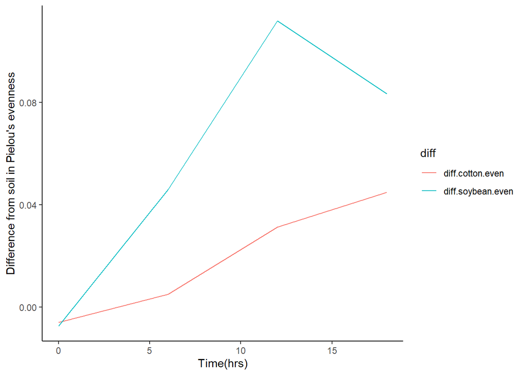

```r
plot<-alpha_average2 %>%
  select(Time_Point,diff.cotton.even,diff.soybean.even) %>% #selecting the columns Time_Point, diff.cotton.even, and diff.soybean.even.
  pivot_longer(c(diff.cotton.even, diff.soybean.even), names_to = "diff") %>% #Using the pivot_longer function to transform the data from wide to long format, creating a new column named diff that contains the values from diff.cotton.even and diff.soybean.even.
  ggplot(aes(Time_Point,value,color=diff))+
  geom_line()+#Using ggplot and geom_line() with ‘Time_Point’ on the x-axis, the column ‘values’ on the y-axis, and different colors for each ‘diff’ category
  xlab("Time(hrs)")+ #Changing x label to match the figure
  ylab("Difference from soil in Pielou's evenness")+ #Changing y label to match the figure
  theme_classic()#Changing theme to classic
plot
```

# Question 7

Commit and push a gfm .md file to GitHub inside a directory called Coding Challenge 5. Provide me a link to your github written as a clickable link in your .pdf or .docx

I have used uploaded the gfm .md file to github inside the directory called **Data_Wrangling** which has both my home and class coding assignment instead of folder named **Coding Challange 5**. The data_Wrangling folder was already created when I did my homework, hence I saved my in class coding challange here too. Here is the link to my github. [My github : https://github.com/ArpanPrj/Reproducibility2025](https://github.com/ArpanPrj/Reproducibility2025)

Here is the link to my .md document [MD document: https://github.com/ArpanPrj/Reproducibility2025/blob/main/Data_Wrangling/Coding_challange_5.md](https://github.com/ArpanPrj/Reproducibility2025/blob/main/Data_Wrangling/Coding_challange_5.md)

I have used .html file instead of .pdf or .docx